# Analysing the effect of land-use type on the proportion of scouts

Joseph Palmer

# Objective

The objective of this study to see if / how land-use influences the proportion of scouts estimated by our model. To do this I carried out both a Principle Component Analysis (PCA) with regression and a Partial Least Squares (PLS) of the land-use data across our sites. I ran both the PLS and PCA on the urban and rural sites separately due to differing land-use categories. This document contains the rational, methods and code for this analysis. At the end of the document I have attempted to write a discussion of these points. This requires more thought to put this into a theoretical framework and is the area I feel most unsure of.

# Method rational

In chapter 1 (outlined in fit_models.Rmd) we fit our models to waggle dance data and estimated the proportion of scouts used by hives in different environments. For chapter 2 I will now try and evaluate what, if any, effect different land-use types have on the proportion scouts estimated by our model. The simplest way to do this would be to perform a regression between the proportion of scouts and the proportion of land-use type across the different sites. However, many land-use types are inherently correlated, for example dense and sparse residential terrain. This analysis therefore requires the use of a multivariate statistic. There are many to choose from but the two most common methods are the Principle Component Analysis (PCA) followed by a regression and Partial Least Squares (PLS).

A PCA regression is done between the main axis of variation in land-use and a response variable. First a PCA is carried out on different factors to produce a linear combination of coefficients that explain the most variation in land-use types. These factors can then be linearly combined in a regression on a response variable. For our study we are interested in how land-use influences proportion of scouts. We would therefore remove the proportion of scouts from the data to start with and perform a PCA on different land-use types to see which combinations best explain the variation. We would then use these combinations of factors as the coefficients for a regression with the proportion of scouts as the response variable.

Alternatively, a PLS is a single step process as unlike the PCA the response variable, in our case proportion of scouts, is not removed from the data. Instead the PLS finds the factors which most contribute to the variation within the response variable, rather than the variation within the land-use types.

In essence, a PCA allows us to test if the main axis of land-use variation between sites is related to the proportion of scouts, where as a PLS is suited to questions about what land-use types most influence the variation in the proportion of scouts (Scott & Crone, 2021). Our question is geared more towards a PLS rather than PCA as we are most interested in what factors most relate to the proportion of scouts, however, both approaches are suitable and will be carried out here.

A key consideration is that our response variable is a proportion and thus lies on the interval $[0, 1]$. This makes it unsuitable for a standard linear regression in the PLS and the PCA regression. One option would be to use a generalized linear regression with a logit link and quasibinomial family. This method is most suited for when the response variable is an integer proportion, where the response variable is a division of two integers, such as the proportion of males within a population. Our measure is in principle an integer proportion as we measure the proportion of scouts, however, this value is an estimate derived from our model and so is continuous on the interval $[0, 1]$. An alternative method would be to transform the proportions on to a continuos scale using the $arcsin \sqrt{x}$ transformation. However, the most appropriate method would be to use a beta regression which is designed specifically for proportional response variables. For the PLS there is a dedicated R package for conducting PLS on proportional data (`plsRbeta`), however, for a PCA we just need to pass the PCA coefficients into a beta regression using the R package `betareg`.

In this document I will conduct a PLS and PCA + regression to investigate how land-use type influences the proportion of scouts in both urban and agri-rural environments.

# Proportion of landuse in Urban and Agri-rural

```r
rural_total_area <- rural_lu[, 3:ncol(rural_lu)] %>%
  colSums()
rural_total_area <- tibble(
  landuse_type = names(rural_total_area), area = rural_total_area
)
rural_total_area$area_pct <- (
  rural_total_area$area / sum(rural_total_area$area)
) * 100

rural_total_area <- rural_total_area %>%
  select(landuse_type, area_pct) %>%
  rename(
    Landuse = landuse_type, "% coverage" = area_pct
  ) %>%
  mutate(
    Landuse = tools::toTitleCase(
      gsub("\\.", " ", rural_total_area$landuse_type)
    ),
    Landuse = ifelse(Landuse == "OSR", "Oilseed Rape", Landuse)
  ) %>%
  rename(
    "Land-use" = Landuse
  )


rural_total_area
```

| Land-use | % coverage |
| --- | --- |
| Woodland | 21.0690077 |
| Non Agricultural Unmanaged Green Space | 2.8114235 |
| Non Agricultural Managed Green Space | 1.7557506 |
| Arable | 28.3364818 |
| Pasture | 23.3359262 |
| Other Agricultural | 1.5001667 |
| Fruit | 3.0781198 |
| Oilseed Rape | 2.9003223 |
| Built Up Area | 15.0350039 |
| Water | 0.1777975 |

```r
urban_total_area <- urban_lu[, 3:ncol(urban_lu)] %>%
  colSums()
urban_total_area <- tibble(
  landuse_type = names(urban_total_area), area = urban_total_area
)
urban_total_area$area_pct <- (
  urban_total_area$area / sum(urban_total_area$area)
) * 100

urban_total_area <- urban_total_area %>%
  select(landuse_type, area_pct) %>%
  rename(
    Landuse = landuse_type, "% coverage" = area_pct
  ) %>%
  mutate(
    Landuse = tools::toTitleCase(
      gsub("\\.", " ", urban_total_area$landuse_type)
    )
  ) %>%
  rename(
    "Land-use" = Landuse
  )

urban_total_area
```

| Land-use | % coverage |
| --- | --- |
| Continuous Central | 24.312706 |
| Dense Residential | 21.783465 |
| Sparse Residential | 34.789563 |
| Parks Allotments Cemeteries | 7.877637 |
| Amenity Grassland | 2.619214 |
| Railway | 1.039688 |
| Woodland | 4.218734 |
| Water | 3.358992 |

```r
save(urban_total_area, rural_total_area, file = "results/area_coverage.RData")
```

# Urban

Here I use both a partial least squares and principle component analysis to investigate how different land-use types in the urban environment most influence the proportion of scouts estimates from our model.

First lets look at the data…

```r
# check the land-use type values sum to 100%
# testthat::test_that(
#   "land-use type values sum to 100",
#   {
#     expected <- rep(100, 10)
#     ans <- rowSums(urban_lu[, 3:ncol(urban_lu)])
#     testthat::expect_identical(expected, ans)
#   }
# )
```

A sanity check on the data shows that the sum of the land-use types for each site doesn’t always sum to 100. This was copied over from the data presented in Samuelson *et al*. (2021).

```r
# look at data
print(urban_lu)
```

```
#> # A tibble: 10 × 10
#> # Groups:   site [10]
#>    site       p continuous.central dense.residential sparse.residential
#>    <chr>  <dbl>              <dbl>             <dbl>              <dbl>
#>  1 BLO   0.209                48.2              24.7               13.6
#>  2 BUR   0.112                26.7              58.8                3.4
#>  3 CAD   1                    28.9              36.4                0.7
#>  4 GIL   0.261                10.8              16.4               63.9
#>  5 HHS   0.0955               13.7              17.9               44.8
#>  6 HOR   0.0557                4.9               3.9               61.7
#>  7 MAK   0.209                10.8               6.2               60.3
#>  8 MPA   0.567                34.4               3.7               47.9
#>  9 SWP   0                    29.9              32.2               15.9
#> 10 ZSL   0.240                34.9              17.7               35.8
#> # … with 5 more variables: parks.allotments.cemeteries <dbl>,
#> #   amenity.grassland <dbl>, railway <dbl>, woodland <dbl>, water <dbl>
```

## PCA

```r
# extract just the lans-use columns
urban.pcadata <- urban_lu[, 3:length(names(urban_lu))]

# run PCA
upca <- prcomp(
  urban.pcadata,
  center = TRUE, scale. = TRUE
)
print(upca)
```

```
#> Standard deviations (1, .., p=8):
#> [1] 1.90766458 1.33812009 1.09646950 0.80884993 0.65628837 0.44349199 0.29388299
#> [8] 0.00036256
#>
#> Rotation (n x k) = (8 x 8):
#>                                     PC1          PC2         PC3         PC4
#> continuous.central          -0.39088080  0.216834742 -0.06357414  0.63385321
#> dense.residential           -0.42687608  0.006903623  0.29172891 -0.54591591
#> sparse.residential           0.47242445  0.062767231 -0.35674469 -0.06387666
#> parks.allotments.cemeteries  0.25716818  0.266521267  0.54314311  0.43629076
#> amenity.grassland            0.42671920 -0.346042614  0.07708896 -0.03398662
#> railway                     -0.07386089 -0.618367993 -0.34833030  0.29926062
#> woodland                     0.14492558 -0.472043332  0.59964779  0.07087016
#> water                       -0.40880380 -0.391167931  0.04155944  0.10020722
#>                                    PC5        PC6         PC7        PC8
#> continuous.central          -0.4478345  0.1674038  0.04603252 0.40457949
#> dense.residential            0.1533928  0.3815291 -0.09062263 0.50724051
#> sparse.residential           0.1161676 -0.3122563 -0.02835211 0.72782256
#> parks.allotments.cemeteries  0.5865377  0.1514945  0.05245403 0.08802489
#> amenity.grassland           -0.2742460  0.5212051  0.58151891 0.07770167
#> railway                      0.3550457  0.3437075 -0.39502581 0.03220278
#> woodland                    -0.3630104 -0.3264733 -0.36129858 0.15057753
#> water                        0.2921449 -0.4578018  0.60113807 0.10862910
```

```r
print(summary(upca))
```

```
#> Importance of components:
#>                           PC1    PC2    PC3     PC4     PC5     PC6    PC7
#> Standard deviation     1.9077 1.3381 1.0965 0.80885 0.65629 0.44349 0.2939
#> Proportion of Variance 0.4549 0.2238 0.1503 0.08178 0.05384 0.02459 0.0108
#> Cumulative Proportion  0.4549 0.6787 0.8290 0.91078 0.96462 0.98920 1.0000
#>                              PC8
#> Standard deviation     0.0003626
#> Proportion of Variance 0.0000000
#> Cumulative Proportion  1.0000000
```

The PCA results contain a number of results, notably the standard deviations and loadings (noted by this package as rotation) of each PC. The standard deviations can be squared to get the variance which can then be used to obtain the percentage variance each PC explains. These are shown in the summary of the PCA model, but deriving them this way allows you to easily make a scree plot to show the percentage variance each PC explains. In addition, each PC can then be compared to the amount of variance they would explain if each PC contributed equally to the variance. This can help in choosing which PCs most contribute to the data.

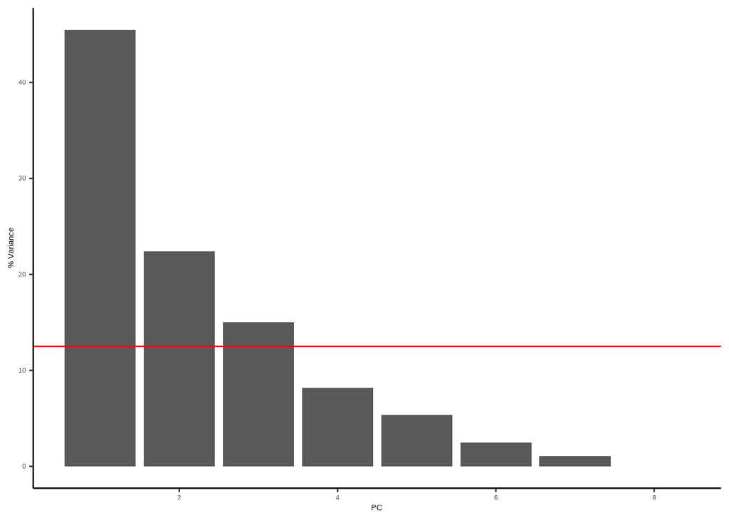

```r
# extract the sd, loadings and scores of the data
sd <- upca$sdev
loadings <- upca$rotation
rownames(loadings) <- colnames(urban.pcadata)
scores <- upca$x

# calculate the variance and percentage of overall variances directly
var <- sd^2
varpercent <- var / sum(var) * 100

# make a scree plot
ggplot(
  data.frame(PC = seq(1, 8), varpercent = varpercent),
  aes(x = PC, y = varpercent)
) +
  geom_bar(stat = "identity") +
  geom_hline(yintercept = 1 / ncol(urban.pcadata) * 100, col = "red") +
  ylab("% Variance")
```

The red line on the plot indicates the expected variance each PC should contribute if they all contributed equally. PCs 1, 2 and 3 explain ~83% of the variance in the data. The loadings can now be evaluated for each of these PCs to identify how each land-use type contributes to the variance in each PC. Again, we can use the expected variance from each land-use if they all equally contributed to find a cut-off.

```r
print(loadings[, 1:3])
```

```
#>                                     PC1          PC2         PC3
#> continuous.central          -0.39088080  0.216834742 -0.06357414
#> dense.residential           -0.42687608  0.006903623  0.29172891
#> sparse.residential           0.47242445  0.062767231 -0.35674469
#> parks.allotments.cemeteries  0.25716818  0.266521267  0.54314311
#> amenity.grassland            0.42671920 -0.346042614  0.07708896
#> railway                     -0.07386089 -0.618367993 -0.34833030
#> woodland                     0.14492558 -0.472043332  0.59964779
#> water                       -0.40880380 -0.391167931  0.04155944
```

```r
sqrt(1 / ncol(urban.pcadata)) # cut off for top loadings
```

```
#> [1] 0.3535534
```

The expected variance each should contribute is around 0.35 and so any values smaller than -0.35 and larger than 0.35 can be said to be contributing more than expected to the variance than under a null model and are thus the main contributors to that PC.

These PCs all show the factors that most explain the variance within land-use types across our study sites. To see how this influences the proportion of scouts I will now do a beta regression of these Principle components.

## Principle Component Regression

Now the PCA is complete we need to relate these major axis of variation (PC1, 2 and 3) to the proportion of scouts. As stated, we cant use a linear model here as the response variable is a proportion, instead we must use a beta regression on the proportion of scouts. These values currently sit on the interval $(0, 1])$ and so must be transformed to lie on the interval $(0, 1)$ via the equation:

$$y = \frac{x (n-1) + s}{n}$$

where $n$ represents the number of data points in $x$ and $s$ represents a constant between 0 and 1. Here, $s$ acts like a Bayesian prior and so we choose $0.5$ to represent an uninformed prior (Smithson & Verkuilen, 2006).

The X attribute of the data (`upca$x`) is the value of the rotated data (centred and scaled) multiplied by the rotation matrix. This is what we use to run the model on as it is the PCs multiplied by the land-use values.

```r
n <- length(urban_lu$p)
y <- (urban_lu$p * (n - 1) + 0.5) / n # transform 1 inflated data
mydata <- cbind(y, data.frame(upca$x))
colnames(mydata)[1] <- "transformed.prop.scouts"
```

Here I will fit the beta regression to the first 3 PCs which collectively explain 83% of the data.

```r
mydata.mod.3 <- betareg(
  transformed.prop.scouts ~ PC1 + PC2 + PC3,
  data = mydata
)
summary(mydata.mod.3)
```

```
#>
#> Call:
#> betareg(formula = transformed.prop.scouts ~ PC1 + PC2 + PC3, data = mydata)
#>
#> Standardized weighted residuals 2:
#>     Min      1Q  Median      3Q     Max
#> -2.3391 -0.5986  0.3734  0.8151  2.9603
#>
#> Coefficients (mean model with logit link):
#>             Estimate Std. Error z value Pr(>|z|)
#> (Intercept)  -0.8452     0.2733  -3.093  0.00198 **
#> PC1          -0.0302     0.1448  -0.209  0.83471
#> PC2           0.2318     0.2066   1.122  0.26181
#> PC3           0.7809     0.2643   2.955  0.00313 **
#>
#> Phi coefficients (precision model with identity link):
#>       Estimate Std. Error z value Pr(>|z|)
#> (phi)    5.900      2.554    2.31   0.0209 *
#> ---
#> Signif. codes:  0 '***' 0.001 '**' 0.01 '*' 0.05 '.' 0.1 ' ' 1
#>
#> Type of estimator: ML (maximum likelihood)
#> Log-likelihood: 5.515 on 5 Df
#> Pseudo R-squared: 0.5719
#> Number of iterations: 23 (BFGS) + 2 (Fisher scoring)
```

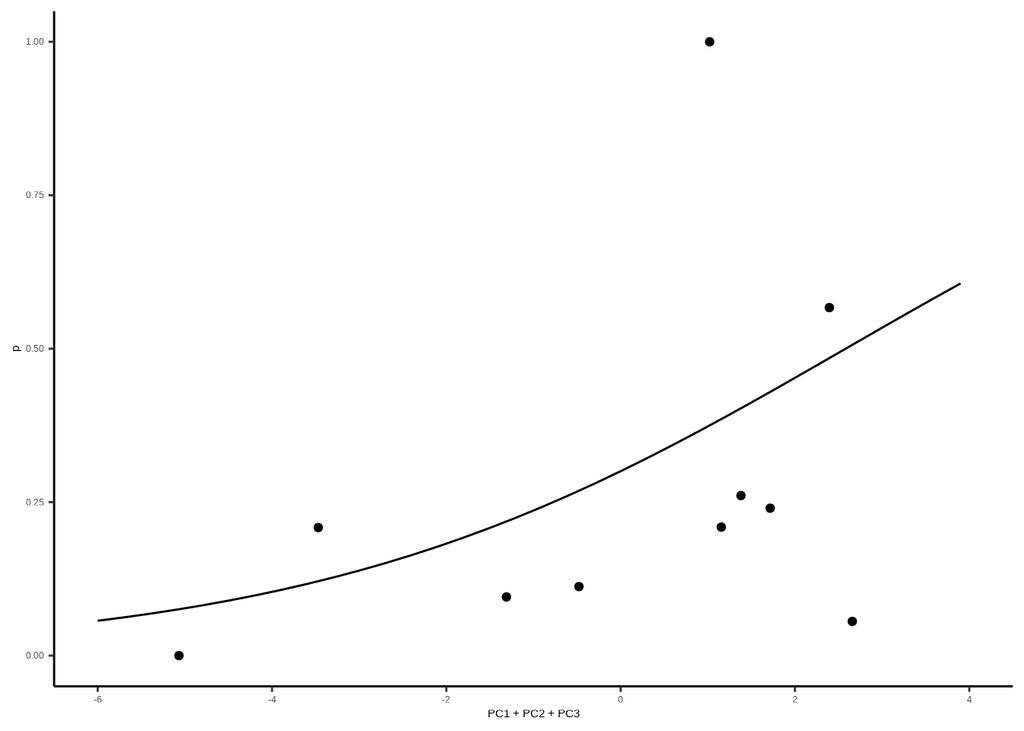

```r
newdat <- data_frame(
  PC1 = seq(-5, 4, 0.1),
  PC2 = seq(-5, 4, 0.1),
  PC3 = seq(-5, 4, 0.1),
)

newdat$fit <- predict(mydata.mod.3, newdat, type = "response")

plotdata <- mydata
plotdata$p <- urban_lu$p

ggplot(data = plotdata, aes(x = PC1 + PC2 + PC3, y = p)) +
  geom_point() +
  geom_line(data = newdat, aes(x = PC1 + PC2 + PC3, y = fit)) +
  xlim(min(-6), max(4))
```

```r
mydata.mod.p3 <- betareg(
  transformed.prop.scouts ~ PC3,
  data = mydata
)
summary(mydata.mod.p3)
```

```
#>
#> Call:
#> betareg(formula = transformed.prop.scouts ~ PC3, data = mydata)
#>
#> Standardized weighted residuals 2:
#>     Min      1Q  Median      3Q     Max
#> -1.9632 -0.5784  0.1647  0.7769  2.2765
#>
#> Coefficients (mean model with logit link):
#>             Estimate Std. Error z value Pr(>|z|)
#> (Intercept)  -0.8386     0.2844  -2.949  0.00319 **
#> PC3           0.7576     0.2756   2.749  0.00599 **
#>
#> Phi coefficients (precision model with identity link):
#>       Estimate Std. Error z value Pr(>|z|)
#> (phi)    5.163      2.216   2.329   0.0198 *
#> ---
#> Signif. codes:  0 '***' 0.001 '**' 0.01 '*' 0.05 '.' 0.1 ' ' 1
#>
#> Type of estimator: ML (maximum likelihood)
#> Log-likelihood: 4.869 on 3 Df
#> Pseudo R-squared: 0.4916
#> Number of iterations: 14 (BFGS) + 1 (Fisher scoring)
```

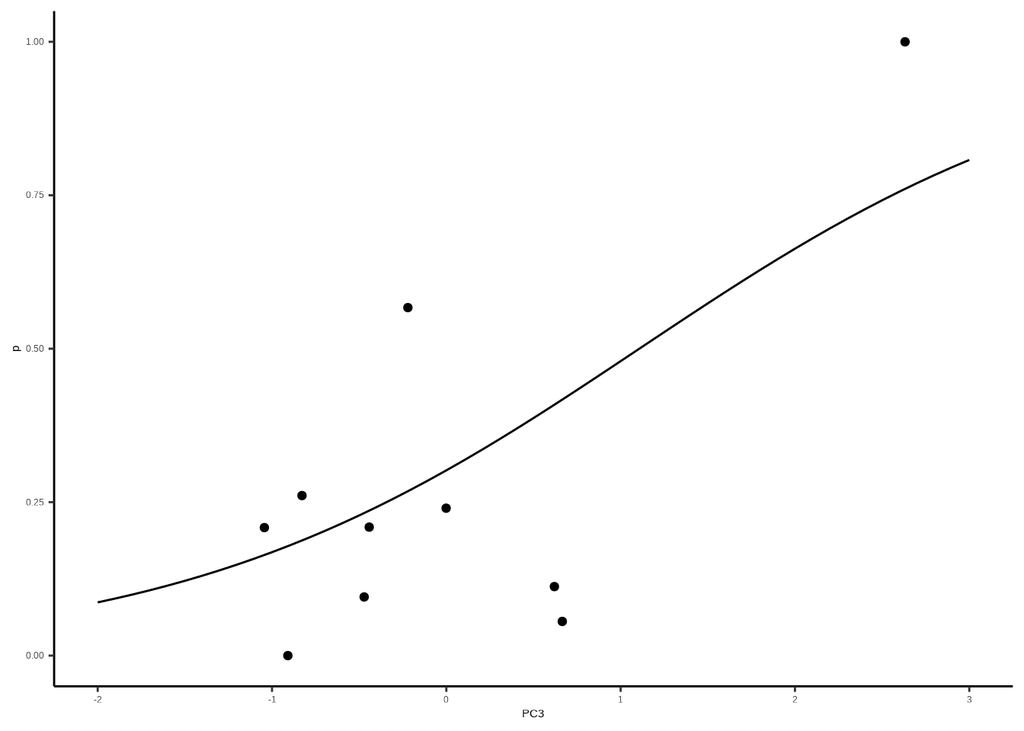

```r
newdat <- data_frame(
  PC1 = seq(-5, 4, 0.1),
  PC2 = seq(-5, 4, 0.1),
  PC3 = seq(-5, 4, 0.1),
)

newdat$fit <- predict(mydata.mod.p3, newdat, type = "response")

plotdata <- mydata
plotdata$p <- urban_lu$p

ggplot(data = plotdata, aes(x = PC3, y = p)) +
  geom_point() +
  geom_line(data = newdat, aes(x = PC3, y = fit)) +
  xlim(min(-2), max(3))
```

Which combination of PCs to use, either PC3 on its own or PC1 + PC2 + PC3, or even PC2 + PC3, can be established through a likelihood ratio test.

```r
mydata.mod.p1_p2 <- betareg(
  transformed.prop.scouts ~ PC2 + PC3,
  data = mydata
)

lrtest(mydata.mod.3, mydata.mod.p3, mydata.mod.p1_p2)
```

|  | #Df | LogLik | Df | Chisq | Pr(>Chisq) |
| --- | --- | --- | --- | --- | --- |
| 1 | 5 | 5.514687 | NA | NA | NA |
| 2 | 3 | 4.868790 | -2 | 1.291793 | 0.5241925 |
| 3 | 4 | 5.491716 | 1 | 1.245851 | 0.2643463 |

The LR test confirms that just using PC3 is the best model.

## PLS

Instead of working out the major axis of variation in land-use across our sites and evaluating how these influence the proportion of scouts, a PLS calculates the principle components which explains the most variation in the proportion of scouts directly.

```r
n <- length(urban_lu$p)
y <- (urban_lu$p * (n - 1) + 0.5) / n
urban.pcadata$p_transform <- y

model <- plsRbeta(
  p_transform ~ .,
  data = urban.pcadata,
  nt = ncol(urban.pcadata) - 2,
  model = "pls-beta",
  verbose = FALSE
)
print(model)
```

```
#> Number of required components:
#> [1] 7
#> Number of successfully computed components:
#> [1] 7
#> Coefficients:
#>                                   [,1]
#> Intercept                   70.6979151
#> continuous.central          -0.7088600
#> dense.residential           -0.7466659
#> sparse.residential          -0.7376743
#> parks.allotments.cemeteries -0.4676195
#> amenity.grassland           -1.1563713
#> railway                     -0.6214822
#> woodland                    -0.5206169
#> water                       -0.8597585
#> Information criteria and Fit statistics:
#>                  AIC       BIC Chi2_Pearson_Y     RSS_Y pseudo_R2_Y      R2_Y
#> Nb_Comp_0   0.862047  1.467217      10.444284 0.6507263          NA        NA
#> Nb_Comp_1 -10.194123 -9.286367       9.581179 0.1596466   0.7327686 0.7546639
#> Nb_Comp_2 -10.834432 -9.624092      11.916059 0.1210103   0.7705154 0.8140381
#> Nb_Comp_3  -9.936420 -8.423494      10.679601 0.1080104   0.7996152 0.8340157
#> Nb_Comp_4  -9.791084 -7.975573       9.397057 0.1014499   0.8612303 0.8440975
#> Nb_Comp_5  -8.398840 -6.280745       9.737823 0.1046884   0.8796405 0.8391207
#> Nb_Comp_6  -6.599692 -4.179011       9.760728 0.1041954   0.8852770 0.8398784
#> Nb_Comp_7  -4.762092 -2.038826       9.897768 0.1044008   0.8914843 0.8395626
```

```r
urban_loadings <- list(
  loadings = model$pp[, 1],
  cutoff = sqrt(1 / (ncol(urban.pcadata) - 1))
)

print(model$pp[, 1:3])
```

```
#>                                Comp_ 1     Comp_ 2    Comp_ 3
#> continuous.central           0.1924916  0.13731384  1.2205428
#> dense.residential            0.1565776 -0.12566736 -0.9993561
#> sparse.residential          -0.2979398 -0.24259279  0.3060919
#> parks.allotments.cemeteries  0.7257963  0.04240446 -0.2097451
#> amenity.grassland           -0.1657878  0.16270121 -0.7111522
#> railway                     -0.5437964  0.79049150 -0.4269126
#> woodland                     0.2595312  0.52722134 -0.6506909
#> water                       -0.1199248  0.58488206 -0.2230112
```

```r
sqrt(1 / (ncol(urban.pcadata) - 1))
```

```
#> [1] 0.3535534
```

```r
plsdata <- data.frame(
  prop.scouts = model$dataY,
  model$tt
)

plsbetamodel <- betareg(
  prop.scouts ~ Comp_.1,
  plsdata
)

summary(plsbetamodel)
```

```
#>
#> Call:
#> betareg(formula = prop.scouts ~ Comp_.1, data = plsdata)
#>
#> Standardized weighted residuals 2:
#>     Min      1Q  Median      3Q     Max
#> -1.6953 -0.8617  0.4554  0.9646  1.9686
#>
#> Coefficients (mean model with logit link):
#>             Estimate Std. Error z value Pr(>|z|)
#> (Intercept)  -0.9530     0.2266  -4.205 2.61e-05 ***
#> Comp_.1       1.0715     0.2351   4.557 5.19e-06 ***
#>
#> Phi coefficients (precision model with identity link):
#>       Estimate Std. Error z value Pr(>|z|)
#> (phi)   10.426      4.607   2.263   0.0236 *
#> ---
#> Signif. codes:  0 '***' 0.001 '**' 0.01 '*' 0.05 '.' 0.1 ' ' 1
#>
#> Type of estimator: ML (maximum likelihood)
#> Log-likelihood: 8.097 on 3 Df
#> Pseudo R-squared: 0.7328
#> Number of iterations: 18 (BFGS) + 4 (Fisher scoring)
```

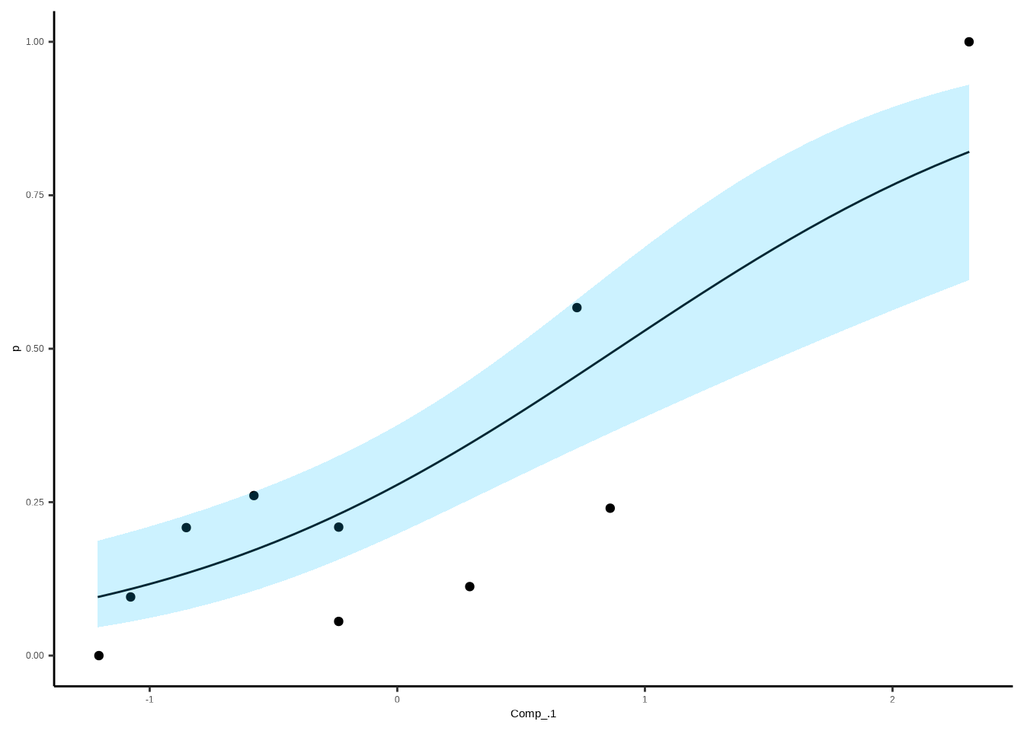

```r
newdat <- data_frame(
  Comp_.1 = seq(
    min(plsdata$Comp_.1),
    max(plsdata$Comp_.1),
    length.out = length(plsdata$Comp_.1)
  )
)

newdat$fit <- predict(plsbetamodel, newdat, type = "response")

# get effects
urban_fitdata <- as.data.frame(predictorEffects(plsbetamodel))$Comp_.1

plotdata <- plsdata
plotdata$p <- urban_lu$p

ggplot(data = plotdata, aes(x = Comp_.1, y = p)) +
  geom_point() +
  geom_line(data = urban_fitdata, aes(x = Comp_.1, y = fit)) +
  geom_ribbon(
    data = urban_fitdata,
    aes(x = Comp_.1, y = fit, ymin = lower, ymax = upper),
    alpha = 0.2,
    fill = "deepskyblue"
  )
```

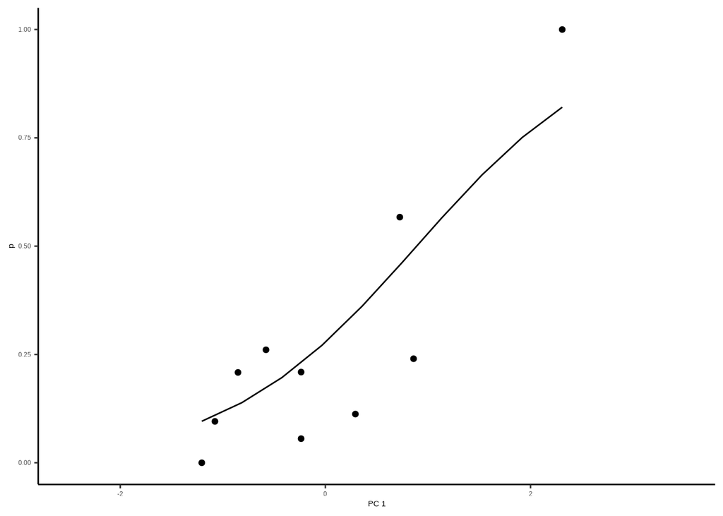

```r
urban.pls <- ggplot(data = plotdata, aes(x = Comp_.1, y = p)) +
  geom_point() +
  geom_line(data = newdat, aes(x = Comp_.1, y = fit)) +
  xlab("PC 1") +
  xlim(min(-2.5), max(3.5))
urban.pls
```

```r
urban_plotdata <- plotdata[, 1:2]
urban_plotdata$`Land-use` <- "Urban"
```

Relatively nice fit. Seems to be the outlier (site where p = 1 ) pulling the proportions up.

```r
plsdata <- data.frame(
  prop.scouts = model$dataY,
  model$tt
)

plsbetamodel.3 <- betareg(
  prop.scouts ~ Comp_.1 + Comp_.2 + Comp_.3,
  plsdata
)

summary(plsbetamodel.3)
```

```
#>
#> Call:
#> betareg(formula = prop.scouts ~ Comp_.1 + Comp_.2 + Comp_.3, data = plsdata)
#>
#> Standardized weighted residuals 2:
#>     Min      1Q  Median      3Q     Max
#> -2.2939 -0.7174  0.4011  0.7951  1.8243
#>
#> Coefficients (mean model with logit link):
#>             Estimate Std. Error z value Pr(>|z|)
#> (Intercept)  -0.9691     0.1967  -4.927 8.36e-07 ***
#> Comp_.1       1.0825     0.2073   5.222 1.77e-07 ***
#> Comp_.2       0.3661     0.2212   1.655   0.0979 .
#> Comp_.3       0.4803     0.4400   1.092   0.2750
#>
#> Phi coefficients (precision model with identity link):
#>       Estimate Std. Error z value Pr(>|z|)
#> (phi)   15.154      6.717   2.256   0.0241 *
#> ---
#> Signif. codes:  0 '***' 0.001 '**' 0.01 '*' 0.05 '.' 0.1 ' ' 1
#>
#> Type of estimator: ML (maximum likelihood)
#> Log-likelihood: 9.968 on 5 Df
#> Pseudo R-squared: 0.7996
#> Number of iterations: 22 (BFGS) + 2 (Fisher scoring)
```

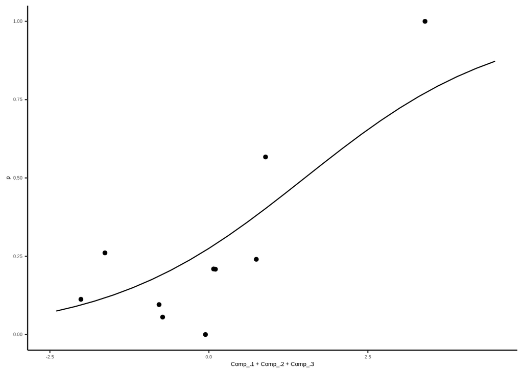

```r
newdat <- data_frame(
  Comp_.1 = seq(-50, 140, 0.1),
  Comp_.2 = seq(-50, 140, 0.1),
  Comp_.3 = seq(-50, 140, 0.1)
)

newdat$fit <- predict(plsbetamodel.3, newdat, type = "response")

plotdata <- plsdata
plotdata$p <- urban_lu$p

ggplot(data = plotdata, aes(x = Comp_.1 + Comp_.2 + Comp_.3, y = p)) +
  geom_point() +
  geom_line(data = newdat, aes(x = Comp_.1 + Comp_.2 + Comp_.3, y = fit)) +
  xlim(min(-2.5), max(4.5))
```

Provides an even nicer looking fit, but is of course a more complex model. Again, we turn to the LR test to decide what to keep.

```r
plsbetamodel.2 <- betareg(
  prop.scouts ~ Comp_.1 + Comp_.2,
  plsdata
)

lrtest(plsbetamodel, plsbetamodel.2, plsbetamodel.3)
```

|  | #Df | LogLik | Df | Chisq | Pr(>Chisq) |
| --- | --- | --- | --- | --- | --- |
| 1 | 3 | 8.097061 | NA | NA | NA |
| 2 | 4 | 9.417216 | 1 | 2.640310 | 0.1041832 |
| 3 | 5 | 9.968210 | 1 | 1.101987 | 0.2938304 |

# Agri-rural

Lets first examine the data…

```r
# # check the land-use type values sum to 100%
# testthat::test_that(
#   "land-use type values sum to 100",
#   {
#     expected <- rep(100, 10)
#     ans <- rowSums(rural_lu[, 3:ncol(rural_lu)])
#     testthat::expect_identical(expected, ans)
#   }
# )
```

A sanity check on the data shows that the sum of the land-use types for each site doesn’t always sum to 100. This was copied over from the data presented in Samuelson *et al*. (2021).

```r
print(rural_lu)
```

```
#> # A tibble: 9 × 12
#> # Groups:   site [9]
#>   site        p woodland Non.agricultural.unman… Non.agricultura… arable pasture
#>   <chr>   <dbl>    <dbl>                   <dbl>            <dbl>  <dbl>   <dbl>
#> 1 BEL   1           21.3                     1                2     41.1    13.9
#> 2 BFI   0.0445      18.5                     0.1              0.4   11.8    28.3
#> 3 HER   1           10.8                     0.4              4.9   66.7    12
#> 4 MEL   0.0797      29.4                    13.3              3.5   14.6     6.6
#> 5 SAU   0.310       18.5                     1.6              0.3   32.8    35
#> 6 SOM   0.00208     28.2                     0.2              0.2   23.1    16.6
#> 7 SRA   0.243       37.8                     1.6              2.9    9.8    27.8
#> 8 STU   1           11                       0.1              0.4   32.8    38.8
#> 9 YAL   0.0801      14.1                     7                1.2   22.3    31
#> # … with 5 more variables: other.agricultural <dbl>, fruit <dbl>, OSR <dbl>,
#> #   built.up.area <dbl>, water <dbl>
```

## PCA

```r
# extract just the lans-use columns
rural.pcadata <- rural_lu[, 3:length(names(rural_lu))]

# run PCA
rpca <- prcomp(
  rural.pcadata,
  center = TRUE, scale. = TRUE
)
print(rpca)
```

```
#> Standard deviations (1, .., p=9):
#> [1] 1.745602e+00 1.541499e+00 1.357948e+00 1.198053e+00 9.358411e-01
#> [6] 5.224511e-01 3.770671e-01 7.979774e-02 2.291341e-16
#>
#> Rotation (n x k) = (10 x 9):
#>                                                PC1         PC2           PC3
#> woodland                               -0.30275120 -0.32326786 -0.1818433024
#> Non.agricultural.unmanaged.green.space -0.33216889 -0.08053499  0.5223044164
#> Non.agricultural.managed.green.space    0.14948239 -0.40892009  0.4721419959
#> arable                                  0.49034583 -0.13691098  0.1746086942
#> pasture                                 0.09319775  0.55841888 -0.2570130422
#> other.agricultural                     -0.36828801 -0.29728428 -0.2384631514
#> fruit                                  -0.28777283  0.18532999  0.0001506741
#> OSR                                    -0.10767826 -0.42961140 -0.4066891842
#> built.up.area                          -0.40233720  0.14743379  0.0053457398
#> water                                  -0.36690137  0.24938380  0.3903585263
#>                                                PC4           PC5         PC6
#> woodland                               -0.26897755  0.5689254871 -0.17339009
#> Non.agricultural.unmanaged.green.space -0.06683424  0.1130986656  0.67967479
#> Non.agricultural.managed.green.space   -0.07719988  0.1670351820 -0.39607336
#> arable                                  0.23866577 -0.2923133068  0.02607069
#> pasture                                -0.08551244  0.2515569600  0.19450027
#> other.agricultural                      0.09699514 -0.5357479961  0.10843116
#> fruit                                   0.64814694  0.1527451452 -0.36085627
#> OSR                                     0.35032696  0.1093570155  0.23343564
#> built.up.area                          -0.44207609 -0.4056941782 -0.33110084
#> water                                   0.32448105  0.0001966854 -0.08061878
#>                                                PC7         PC8         PC9
#> woodland                                0.33114992 -0.21415274  0.41702263
#> Non.agricultural.unmanaged.green.space  0.08670313  0.29402313  0.13289625
#> Non.agricultural.managed.green.space   -0.57738438  0.21596891  0.10013525
#> arable                                  0.26060719 -0.15605753  0.66062244
#> pasture                                -0.49205606  0.11028967  0.49381079
#> other.agricultural                     -0.16084418  0.10234684  0.25181353
#> fruit                                   0.19652974  0.50094397  0.11799896
#> OSR                                    -0.36998013 -0.14823914 -0.03783544
#> built.up.area                          -0.05546722  0.06455084  0.19499645
#> water                                  -0.18696952 -0.70495906  0.03665506
```

```r
print(summary(rpca))
```

```
#> Importance of components:
#>                           PC1    PC2    PC3    PC4     PC5    PC6     PC7
#> Standard deviation     1.7456 1.5415 1.3579 1.1981 0.93584 0.5225 0.37707
#> Proportion of Variance 0.3047 0.2376 0.1844 0.1435 0.08758 0.0273 0.01422
#> Cumulative Proportion  0.3047 0.5423 0.7267 0.8703 0.95785 0.9851 0.99936
#>                            PC8       PC9
#> Standard deviation     0.07980 2.291e-16
#> Proportion of Variance 0.00064 0.000e+00
#> Cumulative Proportion  1.00000 1.000e+00
```

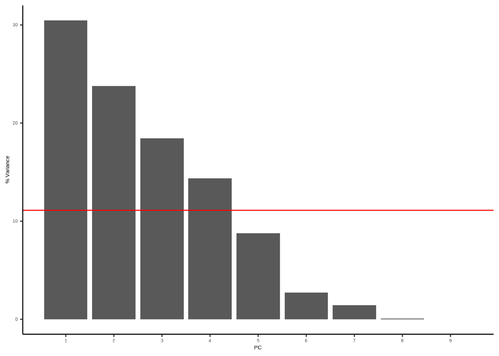

```r
# extract the sd, loadings and scores of the data
sd <- rpca$sdev
loadings <- rpca$rotation
rownames(loadings) <- colnames(rural.pcadata)
scores <- rpca$x

# calculate the variance and percentage of overall variances directly
var <- sd^2
varpercent <- var / sum(var) * 100

# make a scree plot
ggplot(
  data.frame(PC = seq(1, 9), varpercent = varpercent),
  aes(x = PC, y = varpercent)
) +
  geom_bar(stat = "identity") +
  geom_hline(yintercept = 1 / ncol(urban.pcadata) * 100, col = "red") +
  ylab("% Variance") +
  scale_x_continuous(breaks = seq(1, 10))
```

```r
print(loadings[, 1:4])
```

```
#>                                                PC1         PC2           PC3
#> woodland                               -0.30275120 -0.32326786 -0.1818433024
#> Non.agricultural.unmanaged.green.space -0.33216889 -0.08053499  0.5223044164
#> Non.agricultural.managed.green.space    0.14948239 -0.40892009  0.4721419959
#> arable                                  0.49034583 -0.13691098  0.1746086942
#> pasture                                 0.09319775  0.55841888 -0.2570130422
#> other.agricultural                     -0.36828801 -0.29728428 -0.2384631514
#> fruit                                  -0.28777283  0.18532999  0.0001506741
#> OSR                                    -0.10767826 -0.42961140 -0.4066891842
#> built.up.area                          -0.40233720  0.14743379  0.0053457398
#> water                                  -0.36690137  0.24938380  0.3903585263
#>                                                PC4
#> woodland                               -0.26897755
#> Non.agricultural.unmanaged.green.space -0.06683424
#> Non.agricultural.managed.green.space   -0.07719988
#> arable                                  0.23866577
#> pasture                                -0.08551244
#> other.agricultural                      0.09699514
#> fruit                                   0.64814694
#> OSR                                     0.35032696
#> built.up.area                          -0.44207609
#> water                                   0.32448105
```

```r
sqrt(1 / ncol(rural.pcadata)) # cut off for top loadings
```

```
#> [1] 0.3162278
```

The expected variance each should contribute is around 0.32 and so any values smaller than -0.32 and larger than 0.32 can be said to be contributing more than expected to the variance than under a null model and are thus the main contributors to that PC.

These PCs all show the factors that most explain the variance within land-use types across our study sites. To see how this influences the proportion of scouts I will now do a beta regression of these Principle components.

## Principle Component Regression

This regression is carried out with the same rational as the urban sites.

```r
n <- length(rural_lu$p)
y <- (rural_lu$p * (n - 1) + 0.5) / n # transform 1 inflated data
mydata <- cbind(y, data.frame(rpca$x))
colnames(mydata)[1] <- "transformed.prop.scouts"
```

```r
mydata.mod.4 <- betareg(
  transformed.prop.scouts ~ PC1 + PC2 + PC3 + PC4,
  data = mydata
)
summary(mydata.mod.4)
```

```
#>
#> Call:
#> betareg(formula = transformed.prop.scouts ~ PC1 + PC2 + PC3 + PC4, data = mydata)
#>
#> Standardized weighted residuals 2:
#>     Min      1Q  Median      3Q     Max
#> -1.7430 -1.1754 -0.4942  1.5730  2.5213
#>
#> Coefficients (mean model with logit link):
#>             Estimate Std. Error z value Pr(>|z|)
#> (Intercept) -0.18641    0.30971  -0.602 0.547258
#> PC1          0.84245    0.22472   3.749 0.000178 ***
#> PC2         -0.20812    0.21376  -0.974 0.330249
#> PC3         -0.02343    0.24982  -0.094 0.925278
#> PC4          0.22030    0.27445   0.803 0.422139
#>
#> Phi coefficients (precision model with identity link):
#>       Estimate Std. Error z value Pr(>|z|)
#> (phi)    4.240      1.982    2.14   0.0324 *
#> ---
#> Signif. codes:  0 '***' 0.001 '**' 0.01 '*' 0.05 '.' 0.1 ' ' 1
#>
#> Type of estimator: ML (maximum likelihood)
#> Log-likelihood: 5.313 on 6 Df
#> Pseudo R-squared: 0.7025
#> Number of iterations: 23 (BFGS) + 2 (Fisher scoring)
```

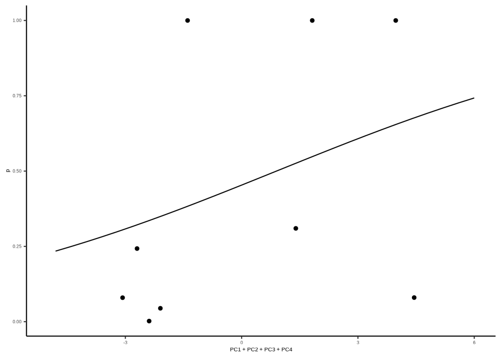

```r
newdat <- data_frame(
  PC1 = seq(-5, 4, 0.1),
  PC2 = seq(-5, 4, 0.1),
  PC3 = seq(-5, 4, 0.1),
  PC4 = seq(-5, 4, 0.1)
)

newdat$fit <- predict(mydata.mod.4, newdat, type = "response")

plotdata <- mydata
plotdata$p <- rural_lu$p

ggplot(data = plotdata, aes(x = PC1 + PC2 + PC3 + PC4, y = p)) +
  geom_point() +
  geom_line(data = newdat, aes(x = PC1 + PC2 + PC3 + PC4, y = fit)) +
  xlim(min(-5), max(6))
```

```r
mydata.mod.p1 <- betareg(
  transformed.prop.scouts ~ PC1,
  data = mydata
)
summary(mydata.mod.p1)
```

```
#>
#> Call:
#> betareg(formula = transformed.prop.scouts ~ PC1, data = mydata)
#>
#> Standardized weighted residuals 2:
#>     Min      1Q  Median      3Q     Max
#> -1.4222 -0.5293 -0.2813  0.5804  2.1035
#>
#> Coefficients (mean model with logit link):
#>             Estimate Std. Error z value Pr(>|z|)
#> (Intercept)  -0.1395     0.3303  -0.422   0.6727
#> PC1           0.7359     0.2319   3.174   0.0015 **
#>
#> Phi coefficients (precision model with identity link):
#>       Estimate Std. Error z value Pr(>|z|)
#> (phi)    3.205      1.449   2.212    0.027 *
#> ---
#> Signif. codes:  0 '***' 0.001 '**' 0.01 '*' 0.05 '.' 0.1 ' ' 1
#>
#> Type of estimator: ML (maximum likelihood)
#> Log-likelihood: 4.422 on 3 Df
#> Pseudo R-squared: 0.6361
#> Number of iterations: 14 (BFGS) + 1 (Fisher scoring)
```

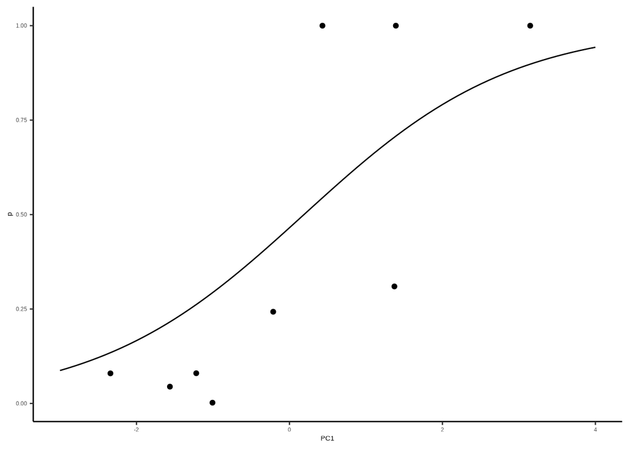

```r
newdat <- data_frame(
  PC1 = seq(-5, 4, 0.1),
  PC2 = seq(-5, 4, 0.1),
  PC3 = seq(-5, 4, 0.1),
)

newdat$fit <- predict(mydata.mod.p1, newdat, type = "response")

plotdata <- mydata
plotdata$p <- rural_lu$p

ggplot(data = plotdata, aes(x = PC1, y = p)) +
  geom_point() +
  geom_line(data = newdat, aes(x = PC1, y = fit)) +
  xlim(min(-3), max(4))
```

```r
mydata.mod.p3 <- betareg(
  transformed.prop.scouts ~ PC3,
  data = mydata
)
summary(mydata.mod.p3)
```

```
#>
#> Call:
#> betareg(formula = transformed.prop.scouts ~ PC3, data = mydata)
#>
#> Standardized weighted residuals 2:
#>     Min      1Q  Median      3Q     Max
#> -1.1634 -0.8357 -0.3271  1.2938  1.4761
#>
#> Coefficients (mean model with logit link):
#>              Estimate Std. Error z value Pr(>|z|)
#> (Intercept) -0.112466   0.406814  -0.276    0.782
#> PC3         -0.008408   0.317082  -0.027    0.979
#>
#> Phi coefficients (precision model with identity link):
#>       Estimate Std. Error z value Pr(>|z|)
#> (phi)   1.2967     0.4902   2.645  0.00816 **
#> ---
#> Signif. codes:  0 '***' 0.001 '**' 0.01 '*' 0.05 '.' 0.1 ' ' 1
#>
#> Type of estimator: ML (maximum likelihood)
#> Log-likelihood: 0.8161 on 3 Df
#> Pseudo R-squared: 0.0001007
#> Number of iterations: 8 (BFGS) + 1 (Fisher scoring)
```

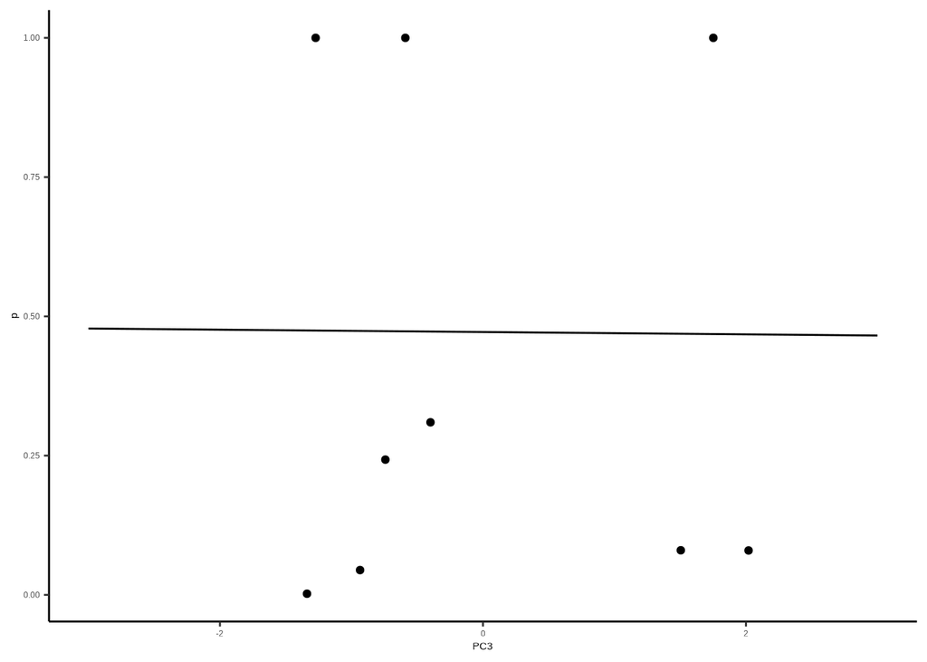

```r
newdat <- data_frame(
  PC1 = seq(-5, 4, 0.1),
  PC2 = seq(-5, 4, 0.1),
  PC3 = seq(-5, 4, 0.1),
)

newdat$fit <- predict(mydata.mod.p3, newdat, type = "response")

plotdata <- mydata
plotdata$p <- rural_lu$p

ggplot(data = plotdata, aes(x = PC3, y = p)) +
  geom_point() +
  geom_line(data = newdat, aes(x = PC3, y = fit)) +
  xlim(min(-3), max(3))
```

```r
lrtest(mydata.mod.p1, mydata.mod.4)
```

|  | #Df | LogLik | Df | Chisq | Pr(>Chisq) |
| --- | --- | --- | --- | --- | --- |
| 1 | 3 | 4.422079 | NA | NA | NA |
| 2 | 6 | 5.312582 | 3 | 1.781006 | 0.619077 |

PC1 seems to be the best model compared to the others according to the LR test, e.g. the more complex model does not explain the data any better.

## PLS

The rational for the PLS follows that used on the urban data.

```r
n <- length(rural_lu$p)
y <- (rural_lu$p * (n - 1) + 0.5) / n
rural.pcadata$p_transform <- y

model <- plsRbeta(
  p_transform ~ .,
  data = rural.pcadata,
  nt = ncol(rural.pcadata) - 1,
  model = "pls-beta",
  verbose = FALSE
)
```

```
#> Error in chol.default(K) :
#>   the leading minor of order 10 is not positive definite
#> Error in chol.default(K) :
#>   the leading minor of order 10 is not positive definite
```

```r
print(model)
```

```
#> Number of required components:
#> [1] 10
#> Number of successfully computed components:
#> [1] 7
#> Coefficients:
#>                                                 [,1]
#> Intercept                               1.580648e+01
#> woodland                               -5.061604e-01
#> Non.agricultural.unmanaged.green.space  3.540517e-01
#> Non.agricultural.managed.green.space    1.353090e+00
#> arable                                 -2.035543e-01
#> pasture                                 9.265016e-05
#> other.agricultural                      2.916255e-01
#> fruit                                   5.453254e-01
#> OSR                                     4.895588e-02
#> built.up.area                          -1.300082e-01
#> water                                  -1.843074e+01
#> Information criteria and Fit statistics:
#>                  AIC        BIC Chi2_Pearson_Y       RSS_Y pseudo_R2_Y
#> Nb_Comp_0   2.368550   2.762999      11.816469 1.263930369          NA
#> Nb_Comp_1  -5.693014  -5.101341       8.023902 0.284717887   0.7337093
#> Nb_Comp_2  -8.730710  -7.941811       8.038859 0.136271693   0.8429930
#> Nb_Comp_3 -11.569019 -10.582897       8.686277 0.095491593   0.9186679
#> Nb_Comp_4 -13.071900 -11.888552       8.386914 0.044872859   0.9253180
#> Nb_Comp_5 -12.919238 -11.538666      12.240066 0.028552628   0.9179997
#> Nb_Comp_6 -18.000878 -16.423082      29.810734 0.005890361   0.9281714
#> Nb_Comp_7 -39.382653 -37.607632       8.995468 0.000920072   0.9972658
#>                R2_Y
#> Nb_Comp_0        NA
#> Nb_Comp_1 0.7747361
#> Nb_Comp_2 0.8921842
#> Nb_Comp_3 0.9244487
#> Nb_Comp_4 0.9644974
#> Nb_Comp_5 0.9774097
#> Nb_Comp_6 0.9953396
#> Nb_Comp_7 0.9992721
```

```r
agrirural_loadings <- list(
  loadings = model$pp[, 1],
  cutoff = sqrt(1 / (ncol(rural.pcadata) - 1))
)

model$pp[, 1:3]
```

```
#>                                             Comp_ 1    Comp_ 2     Comp_ 3
#> woodland                               -0.287113036 -0.5423752 -0.01826005
#> Non.agricultural.unmanaged.green.space -0.314626127  0.5668561 -0.70283985
#> Non.agricultural.managed.green.space    0.214784908  0.2691964 -0.88776609
#> arable                                  0.546458419  0.3349290 -0.56906309
#> pasture                                -0.029336269 -0.6931260  1.26623185
#> other.agricultural                     -0.282285426  0.8936489  0.04562882
#> fruit                                  -0.285158265  0.1484698 -0.77100501
#> OSR                                    -0.003826055  0.4828161  0.19145254
#> built.up.area                          -0.449631721  0.0242609  0.29080975
#> water                                  -0.387801804  0.4334921 -0.80213012
```

```r
sqrt(1 / (ncol(rural.pcadata) - 1))
```

```
#> [1] 0.3162278
```

```r
plsdata <- data.frame(
  prop.scouts = model$dataY,
  model$tt
)

plsbetamodel <- betareg(
  prop.scouts ~ Comp_.1,
  plsdata
)

summary(plsbetamodel)
```

```
#>
#> Call:
#> betareg(formula = prop.scouts ~ Comp_.1, data = plsdata)
#>
#> Standardized weighted residuals 2:
#>     Min      1Q  Median      3Q     Max
#> -1.5735 -0.9622  0.0785  0.5919  1.9177
#>
#> Coefficients (mean model with logit link):
#>             Estimate Std. Error z value Pr(>|z|)
#> (Intercept)  -0.1605     0.2979  -0.539     0.59
#> Comp_.1       0.9663     0.2296   4.209 2.57e-05 ***
#>
#> Phi coefficients (precision model with identity link):
#>       Estimate Std. Error z value Pr(>|z|)
#> (phi)    4.933      2.330   2.118   0.0342 *
#> ---
#> Signif. codes:  0 '***' 0.001 '**' 0.01 '*' 0.05 '.' 0.1 ' ' 1
#>
#> Type of estimator: ML (maximum likelihood)
#> Log-likelihood: 5.847 on 3 Df
#> Pseudo R-squared: 0.7337
#> Number of iterations: 21 (BFGS) + 1 (Fisher scoring)
```

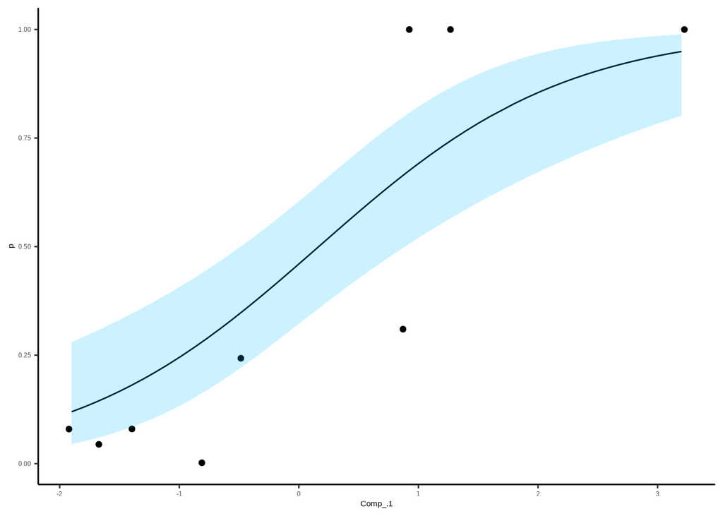

```r
newdat <- data_frame(
  Comp_.1 = seq(
    min(plsdata$Comp_.1),
    max(plsdata$Comp_.1),
    length.out = length(plsdata$Comp_.1)
  )
)

newdat$fit <- predict(plsbetamodel, newdat, se.fit = TRUE, type = "response")

rural_fitdata <- as.data.frame(predictorEffects(plsbetamodel))$Comp_.1

plotdata <- plsdata
plotdata$p <- rural_lu$p

ggplot(data = plotdata, aes(x = Comp_.1, y = p)) +
  geom_point() +
  geom_line(data = rural_fitdata, aes(x = Comp_.1, y = fit)) +
  geom_ribbon(
    data = rural_fitdata,
    aes(x = Comp_.1, y = fit, ymin = lower, ymax = upper),
    alpha = 0.2,
    fill = "deepskyblue"
  )
```

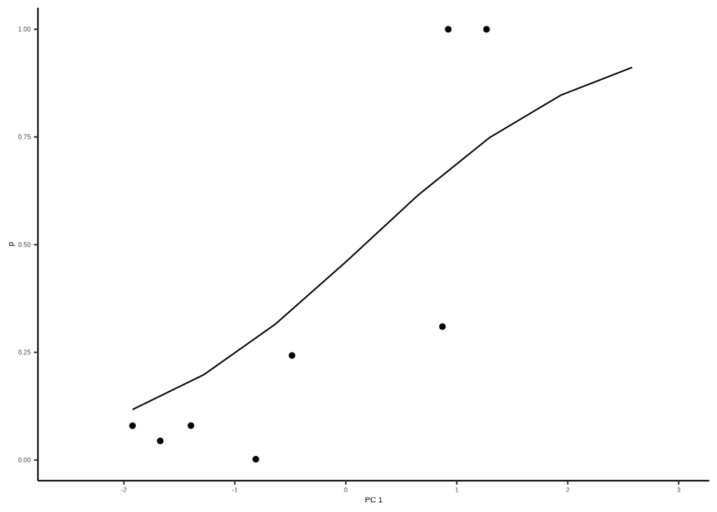

```r
agri.rural.pls <- ggplot(data = plotdata, aes(x = Comp_.1, y = p)) +
  geom_point() +
  geom_line(data = newdat, aes(x = Comp_.1, y = fit)) +
  xlab("PC 1") +
  xlim(min(-2.5), max(3.))
agri.rural.pls
```

```r
agrirural_plotdata <- plotdata[, 1:2]
agrirural_plotdata$`Land-use` <- "Agri-rural"
```

Even with a lack of data, this looks like a pretty good relationship!

```r
plsdata <- data.frame(
  prop.scouts = model$dataY,
  model$tt
)

plsbetamodel.3 <- betareg(
  prop.scouts ~ Comp_.1 + Comp_.2 + Comp_.3,
  plsdata
)

summary(plsbetamodel.3)
```

```
#>
#> Call:
#> betareg(formula = prop.scouts ~ Comp_.1 + Comp_.2 + Comp_.3, data = plsdata)
#>
#> Standardized weighted residuals 2:
#>     Min      1Q  Median      3Q     Max
#> -2.3806 -0.1639  0.2584  0.6911  2.1512
#>
#> Coefficients (mean model with logit link):
#>             Estimate Std. Error z value Pr(>|z|)
#> (Intercept)  -0.3286     0.2217  -1.482   0.1383
#> Comp_.1       1.0522     0.1552   6.779 1.21e-11 ***
#> Comp_.2       1.1987     0.3916   3.061   0.0022 **
#> Comp_.3       1.1516     0.4971   2.317   0.0205 *
#>
#> Phi coefficients (precision model with identity link):
#>       Estimate Std. Error z value Pr(>|z|)
#> (phi)   15.692      7.471     2.1   0.0357 *
#> ---
#> Signif. codes:  0 '***' 0.001 '**' 0.01 '*' 0.05 '.' 0.1 ' ' 1
#>
#> Type of estimator: ML (maximum likelihood)
#> Log-likelihood: 10.78 on 5 Df
#> Pseudo R-squared: 0.9187
#> Number of iterations: 45 (BFGS) + 5 (Fisher scoring)
```

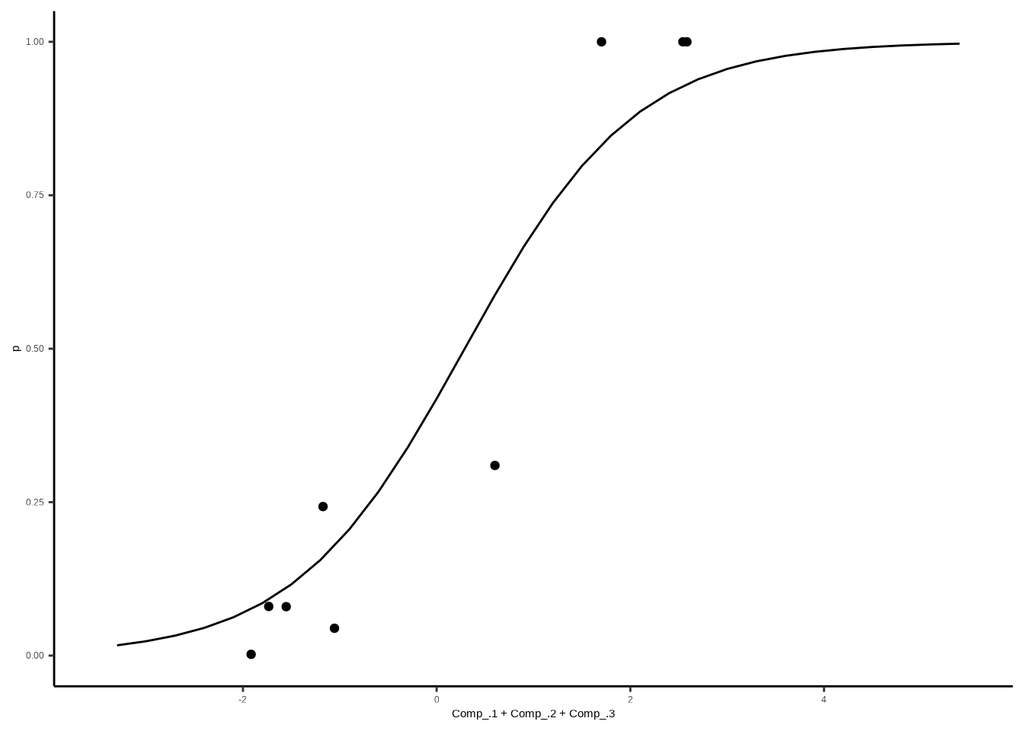

```r
newdat <- data_frame(
  Comp_.1 = seq(-50, 140, 0.1),
  Comp_.2 = seq(-50, 140, 0.1),
  Comp_.3 = seq(-50, 140, 0.1)
)

newdat$fit <- predict(plsbetamodel.3, newdat, type = "response")

plotdata <- plsdata
plotdata$p <- rural_lu$p

ggplot(data = plotdata, aes(x = Comp_.1 + Comp_.2 + Comp_.3, y = p)) +
  geom_point() +
  geom_line(data = newdat, aes(x = Comp_.1 + Comp_.2 + Comp_.3, y = fit)) +
  xlim(min(-3.5), max(5.5))
```

Good looking relationship, but what does the LRT say?

```r
plsbetamodel.2 <- betareg(
  prop.scouts ~ Comp_.1 + Comp_.2,
  plsdata
)

lrtest(plsbetamodel, plsbetamodel.2, plsbetamodel.3)
```

|  | #Df | LogLik | Df | Chisq | Pr(>Chisq) |
| --- | --- | --- | --- | --- | --- |
| 1 | 3 | 5.846507 | NA | NA | NA |
| 2 | 4 | 8.365355 | 1 | 5.037695 | 0.02480147 |
| 3 | 5 | 10.784510 | 1 | 4.838310 | 0.02783416 |

# Discussion / Conclusions

Here I have walked through a PCA + beta regression and PLS analysis on both the urban and agri-rural datasets. Both of these methods reveal interesting relationships between the proportion of scouts and land-use types in urban and agri-rural environments. In both environments we are able to identify principle components which show a singificant relationship with our estimated proportion of scouts. The tricky part is placing these in a theoretical framework about how the environment influences foraging behaviours by a colony.

In the urban environment, the PCA + regression identifies three main axis of variation, yet it is only the third PC which has a singificant relationship with the proportion of scouts. This PC increases with parks, allotments, cemeteries and woodland whilst decreasing with sparse residential and railway. In essence, this suggests a landscape with higher residential areas as increasing the proportion of scouts, whilst more green spaces (parks, allotments and cemeteries and woodlands) decreases the proportion of scouts, suggesting more reliable foraging grounds. However, the relationship here is rather weak ($R^2$ = 0.38). This is likely due to the nature of the PCA. The PCA finds the priniciple axis of variation in the data rather than our response variable. Consequently, we end up only evaluating the effect of the main axis of variation in land-use type on the proportion of scouts. The PLS allows us to directly evaluate the land-use types most contributing to the proportion of scouts.

Just like the PCA, the PLS identifies 3 major axis of variation which together explain 88% of the variation in the proportion of scouts. Both in isolation and combined, these three PCs have a singificant positive correlation with the proportion of scouts. The best fit comes from a combination of these three PCs. Collectively, these first three PCs correlate positively with continous central land, parks allotments and cemeteries,railway and water, and correlate negatively with dense residential areas and amenity grassland. Unlike with the PCA, this relationship is fairly strong ($R^2 = 0.88$) So, in environments where there are more green spaces (parks, allotments, woodland etc.), more continous central land and water, along with less residential and grasslands, honeybee colonies use a scout dominant foraging strategy.

These results suggests in urban environments, when forage is easy to find (open spaces?) colonies send out more scouts rather than optimising information by using recruits. When resources are harder to find a colony uses more recruits. This suggests, in urban environments at least, that the waggle dance is more benefician when resources are harder to find. However, it should be noted that this relationship may be biased by the single site where the proportion of scouts sat at 100%.

In the agri-rural environment the PCA + regression identifies 4 main axis of variation explaining 83% of the variation in the data, yet it is PCs 1 and 3 which show a singificant relationship with the proportion of scouts. PC1 describes the most variation in the data (~29%) and is a singificantly more parsimonious model than just PC3 or all four Pcs combined. PC1 correlates positively with arable land and negatively with woodland, Non agricultural managed green space, other agricultural, fruit and water. PC3, which correlates negatively with the proportion of scouts, correlates negatively with woodland and OSR, whilst correlating positively with Non agricultural unmanaged and managed green spaces and built up areas. Combined, these results sort of follow the results for the urban data, that when resources are easier to find a colony uses more recruits, where as when resources are harder to find they use more scouts. Again though, only ~30% of the variation is accounted for and so the association is quite weak.

# Figures, results write up and main discussion points

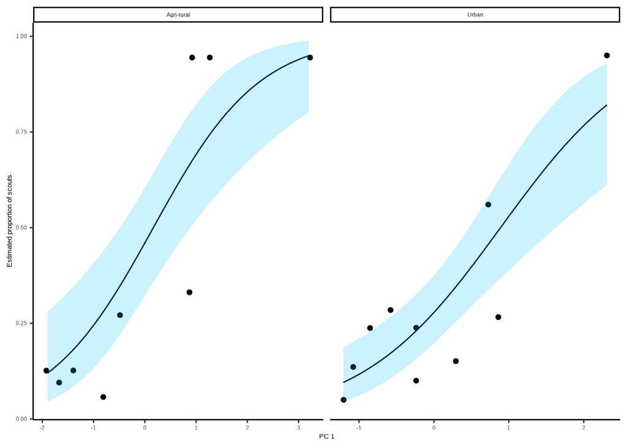

```r
# load loadings data from the jk analysis
loading_path <- "results/pls-loadings.RData"
if (file.exists(loading_path)) {
  load(loading_path)
} else {
  stop(
    paste(
      "File", loading_path, "not found.",
      "Please run the notebook `landuse_effect_jackknife.Rmd` to create it."
    )
  )
}


plotdata <- rbind(urban_plotdata, agrirural_plotdata)
urban_fitdata$`Land-use` <- "Urban"
rural_fitdata$`Land-use` <- "Agri-rural"
fit_data <- rbind(urban_fitdata, rural_fitdata)

landuse_plots <- ggplot(data = plotdata, aes(x = Comp_.1, y = prop.scouts)) +
  geom_point() +
  geom_line(data = fit_data, aes(x = Comp_.1, y = fit)) +
  geom_ribbon(
    data = fit_data,
    aes(x = Comp_.1, y = fit, ymin = lower, ymax = upper),
    alpha = 0.2,
    fill = "deepskyblue"
  ) +
  xlab("PC 1") +
  ylab("Estimated proportion of scouts") +
  facet_wrap(~`Land-use`, nrow = 1, scales = "free_x")

ggsave(
  plot = landuse_plots,
  filename = "results/figures/landuse_plots.png",
  width = 183,
  height = 190,
  units = "mm",
  dpi = 300
)

landuse_plots
```

```r
urban_fit <- ggplot(data = urban_plotdata, aes(x = Comp_.1, y = prop.scouts)) +
  geom_point() +
  geom_line(data = urban_fitdata, aes(x = Comp_.1, y = fit)) +
  geom_ribbon(
    data = urban_fitdata,
    aes(x = Comp_.1, y = fit, ymin = lower, ymax = upper),
    alpha = 0.2,
    fill = "deepskyblue"
  ) +
  xlab("PC 1") +
  ylab("Estimated proportion of scouts")

agri_rural_fit <- ggplot(data = agrirural_plotdata, aes(x = Comp_.1, y = prop.scouts)) +
  geom_point() +
  geom_line(data = rural_fitdata, aes(x = Comp_.1, y = fit)) +
  geom_ribbon(
    data = rural_fitdata,
    aes(x = Comp_.1, y = fit, ymin = lower, ymax = upper),
    alpha = 0.2,
    fill = "deepskyblue"
  ) +
  xlab("PC 1") +
  ylab("Estimated proportion of scouts")

ggsave(
  plot = urban_fit,
  filename = "results/figures/urban_fit.png",
  width = 183,
  height = 190,
  units = "mm",
  dpi = 300
)

ggsave(
  plot = agri_rural_fit,
  filename = "results/figures/agrirural_fit.png",
  width = 183,
  height = 190,
  units = "mm",
  dpi = 300
)
```

## Land-use maps

Here I create figures which show the relationship between PC1 and the proportion of scouts as well as land-use maps of sites long the gradient which are coloured by the land-use types identified as most singificant in the PLS (PC1).

### Agri-rural

```r
library(sf)
library(sp)
library(ggspatial)

textsize <- 8

# load land-use conversion table
luconversions <- read.csv("data/LUCategoryConversion.csv")
agrirural_luconversions <- luconversions %>%
  filter(LU == "agri-rural")

# make fit map with agrirural landuses
agrirural_plotdata$site <- rural_lu$site
agrirural_plotdata$prop_scouts <- rural_lu$p
ar_sortedpropscouts <- arrange(agrirural_plotdata, prop_scouts) %>%
  filter(site != "ROT")

print(ar_sortedpropscouts)
```

```
#>   prop.scouts    Comp_.1   Land-use site prop_scouts
#> 6  0.05740376 -0.8109691 Agri-rural  SOM 0.002079226
#> 2  0.09514871 -1.6724419 Agri-rural  BFI 0.044542294
#> 4  0.12642171 -1.9221409 Agri-rural  MEL 0.079724428
#> 9  0.12671909 -1.3955931 Agri-rural  YAL 0.080058974
#> 7  0.27139161 -0.4849915 Agri-rural  SRA 0.242815567
#> 5  0.33093833  0.8710209 Agri-rural  SAU 0.309805626
#> 1  0.94444444  1.2680858 Agri-rural  BEL 1.000000000
#> 3  0.94444444  3.2238197 Agri-rural  HER 1.000000000
#> 8  0.94444444  0.9232101 Agri-rural  STU 1.000000000
```

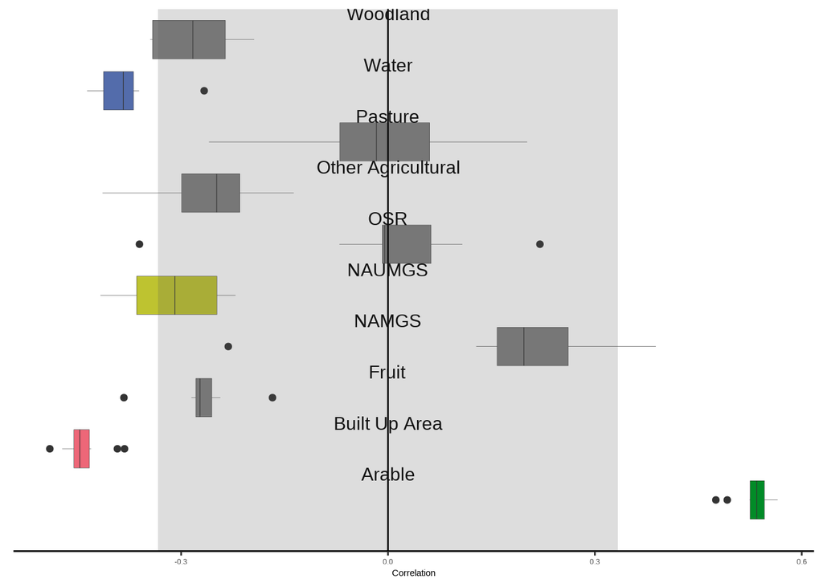

```r
# select sites to draw attention to, those sitting on the trend
ar_marked <- ar_sortedpropscouts %>%
  filter(site %in% c("MEL", "SRA", "HER"))

# make model fit graph of pc1 against prop scouts and mark the sites
ar_fit <- ggplot(
  data = ar_sortedpropscouts, aes(x = Comp_.1, y = prop_scouts)
) +
  geom_point() +
  geom_line(data = rural_fitdata, aes(x = Comp_.1, y = fit)) +
  geom_ribbon(
    data = rural_fitdata,
    aes(x = Comp_.1, y = fit, ymin = lower, ymax = upper),
    alpha = 0.2,
    fill = "deepskyblue"
  ) +
  geom_point(
    data = ar_marked, aes(x = Comp_.1, y = prop_scouts, colour = "red")
  ) +
  geom_text(
    data = ar_marked, aes(x = Comp_.1, y = prop_scouts, label = site),
    nudge_x = c(0, 0), nudge_y = c(-0.05, 0.05), size = rel(textsize)
  ) +
  theme_classic() +
  theme(legend.position = "none", text = element_text(size = rel(textsize - 2))) +
  xlab("PC 1") +
  ylab("Estimated proportion of scouts")

# make the maps for each of the sites selected in the previous step
site_shape_data_ar <- list()
site_plots <- list()
for (i in seq_len(3)) {
  path <- paste0(
    "shapefiles/agri-rural/",
    ar_marked[i, "site"], "/", ar_marked[i, "site"],
    ".shp"
  )
  df <- st_read(path) %>%
    st_transform(
      CRS("+proj=longlat +datum=WGS84 +no_defs +ellps=WGS84 +towgs84=0,0,0")
    )
  # add major LU categories
  df_merged <- df %>%
    mutate(descriptio = toupper(descriptio)) %>%
    full_join(agrirural_luconversions, by = c("descriptio" = "code"))
  site_shape_data_ar[[ar_marked[i, "site"]]] <- df_merged
  site_plots[[ar_marked[i, "site"]]] <- ggplot() +
    geom_sf(
      data = df_merged,
      aes(fill = category)
    ) +
    theme_void() +
    scale_fill_manual(
      values = c(
        "arable" = "#018B27", "built-up area" = "#ED6778",
        "Non-agricultural unmanaged green space" = "#BEC330",
        "water" = "#536CAB", "pasture" = "#BBBBBB", "woodland" = "#BBBBBB",
        "Non-agricultural managed green space" = "#BBBBBB", "fruit" = "#BBBBBB",
        "OSR" = "#BBBBBB", "other agricultural" = "#BBBBBB"
      )
    )
}
# make loadings plot
argi.rural.loadings <- rural_jk_loadings %>%
  rename(
    Landuse = landuse_type,
    Correlation = loadings
  ) %>%
  mutate(
    Landuse = tools::toTitleCase(
      gsub("\\.", " ", rural_jk_loadings$landuse_type)
    ),
    significant = ifelse(
      Correlation > rural_jk_loadings$cutoff,
      Landuse,
      ifelse(
        Correlation < -rural_jk_loadings$cutoff,
        Landuse,
        "Other"
      )
    ),
    Landuse = ifelse(
      Landuse == "Non Agricultural Managed Green Space",
      "NAMGS",
      ifelse(
        Landuse == "Non Agricultural Unmanaged Green Space",
        "NAUMGS",
        Landuse
      )
    )
  )

cutoff <- unique(argi.rural.loadings$cutoff)[[1]]

rural_loading_text <- tibble(
  landuse_type = unique(argi.rural.loadings$Landuse), result = 0
)

loading_plot <- ggplot(
  data = argi.rural.loadings,
  aes(
    x = Landuse, y = Correlation
  )
) +
  geom_boxplot(aes(fill = Landuse), lwd = 0.1) +
  geom_hline(
    yintercept = 0, color = "black"
  ) +
  geom_text(
    data = rural_loading_text,
    aes(x = landuse_type, y = result, label = landuse_type),
    hjust = 0.5,
    vjust = 0.5,
    nudge_y = c(-0., -0.), nudge_x = c(0.5, 0.5), size = rel(textsize)
  ) +
  annotate(
    "rect",
    ymin = -cutoff,
    ymax = cutoff,
    xmin = 0, xmax = Inf,
    alpha = 0.2
  ) +
  coord_flip() +
  theme_classic() +
  theme(
    axis.line.y = element_blank(),
    axis.title.y = element_blank(),
    axis.text.y = element_blank(),
    axis.ticks.y = element_blank(),
    legend.position = "None",
    text = element_text()
  ) +
  scale_fill_manual(
    values = c(
      "Arable" = "#018B27", "Built Up Area" = "#ED6778",
      "NAUMGS" = "#BEC330",
      "Water" = "#536CAB", Other = "#BBBBBB"
    )
  )

loading_plot
```

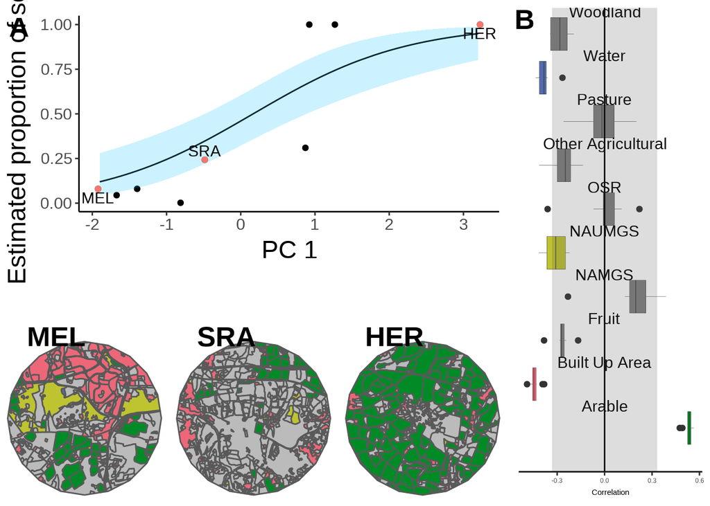

```r
# combine plots into facet

# MAPS BELLOW PLOT
# first the maps in a column of three
sitelumaps <- plot_grid(
  site_plots[[1]] + theme(
    legend.position = "none",
    plot.margin = unit(c(0., 0., -1.2, 0.), "cm")
  ),
  site_plots[[2]] + theme(
    legend.position = "none",
    plot.margin = unit(c(0., 0., -1.2, 0.), "cm")
  ),
  site_plots[[3]] + theme(
    legend.position = "none",
    plot.margin = unit(c(0., 0., -1.2, 0.), "cm")
  ),
  nrow = 1,
  align = "h",
  labels = c(
    names(site_plots)[1], names(site_plots)[2], names(site_plots)[3]
  ),
  label_size = rel(textsize * 5)
)

mfitpls <- plot_grid(
  ar_fit + theme(plot.margin = unit(c(0.2, 0.2, 1.2, 0.2), "cm")),
  sitelumaps,
  ncol = 1,
  align = "l",
  rel_heights = c(1, .5),
  labels = c(
    "A", ""
  ),
  label_size = rel(textsize * 5)
)

# all together
comb <- plot_grid(
  mfitpls, loading_plot,
  nrow = 1, align = "h",
  rel_widths = c(1, .4),
  labels = c("", "B", ""),
  label_size = rel(textsize * 5)
)

comb
```

```r
ggsave(
  plot = comb,
  filename = "results/figures/lu_prop_scouts_agrirural.png",
  width = 183,
  height = 183,
  units = "mm",
  dpi = 300
)

ggsave(
  plot = comb,
  filename = "results/figures/lu_prop_scouts_agrirural.svg",
  width = 183,
  height = 183,
  units = "mm",
  dpi = 300
)
```

### Urban

```r
# load land-use conversion table
luconversions <- read.csv("data/LUCategoryConversion.csv")
urban_luconversions <- luconversions %>%
  filter(LU == "urban")

# make fit map with agrirural landuses
urban_plotdata$site <- urban_lu$site
urban_plotdata$prop_scouts <- urban_lu$p
u_sortedpropscouts <- arrange(urban_plotdata, prop_scouts)

print(u_sortedpropscouts)
```

```
#>    prop.scouts    Comp_.1 Land-use site prop_scouts
#> 9    0.0500000 -1.2051684    Urban  SWP  0.00000000
#> 6    0.1001140 -0.2368054    Urban  HOR  0.05568226
#> 5    0.1359904 -1.0770168    Urban  HHS  0.09554494
#> 2    0.1511947  0.2925633    Urban  BUR  0.11243853
#> 1    0.2376835 -0.8521616    Urban  BLO  0.20853719
#> 7    0.2384109 -0.2366906    Urban  MAK  0.20934543
#> 10   0.2661484  0.8597428    Urban  ZSL  0.24016486
#> 4    0.2846566 -0.5791009    Urban  GIL  0.26072958
#> 8    0.5602634  0.7255026    Urban  MPA  0.56695935
#> 3    0.9500000  2.3091349    Urban  CAD  1.00000000
```

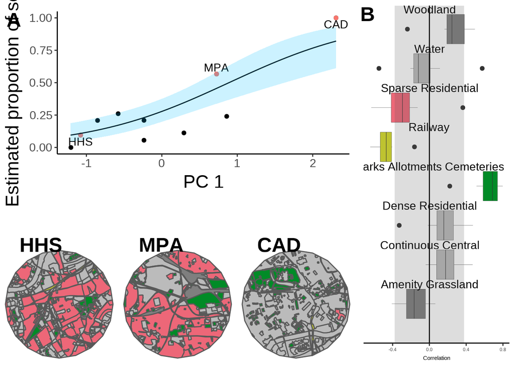

```r
u_marked <- u_sortedpropscouts %>%
  filter(site %in% c("HHS", "MPA", "CAD"))

# make model fit graph of pc1 against prop scouts and mark the sites with the
# lowest, middle and highest proportion of scouts
u_fit <- ggplot(
  data = u_sortedpropscouts, aes(x = Comp_.1, y = prop_scouts)
) +
  geom_point() +
  geom_point(
    data = u_marked, aes(x = Comp_.1, y = prop_scouts, colour = "red")
  ) +
  geom_text(
    data = u_marked, aes(x = Comp_.1, y = prop_scouts, label = site),
    nudge_x = c(0, 0), nudge_y = c(-0.05, 0.05), size = rel(textsize)
  ) +
  geom_line(data = urban_fitdata, aes(x = Comp_.1, y = fit)) +
  geom_ribbon(
    data = urban_fitdata,
    aes(x = Comp_.1, y = fit, ymin = lower, ymax = upper),
    alpha = 0.2,
    fill = "deepskyblue"
  ) +
  theme_classic() +
  theme(legend.position = "none", text = element_text(size = rel(textsize - 2))) +
  xlab("PC 1") +
  ylab("Estimated proportion of scouts")

# make the maps for each of the sites selected in the previous step
site_shape_data_u <- list()
site_plots <- list()
for (i in seq_len(3)) {
  path <- paste0(
    "shapefiles/urban/",
    u_marked[i, "site"], "/", u_marked[i, "site"],
    ".shp"
  )
  df <- st_read(path) %>%
    st_transform(
      CRS("+proj=longlat +datum=WGS84 +no_defs +ellps=WGS84 +towgs84=0,0,0")
    )
  # add major LU categories
  df_merged <- df %>%
    mutate(descriptio = toupper(descriptio)) %>%
    full_join(urban_luconversions, by = c("descriptio" = "code"))
  site_shape_data_u[[u_marked[i, "site"]]] <- df_merged
  site_plots[[u_marked[i, "site"]]] <- ggplot() +
    geom_sf(
      data = df_merged,
      aes(fill = category)
    ) +
    theme_void() +
    scale_fill_manual(
      values = c(
        "continuous central" = "#BBBBBB", "dense residential" = "#BBBBBB",
        "sparse residential" = "#ED6778", "amenity grassland" = "#BBBBBB",
        "water" = "#BBBBBB", "parks allotments cemeteries" = "#018B27",
        "Railway" = "#BEC330", "woodland" = "#BBBBBB"
      )
    )
}
# make loadings plot
urban.loadings <- urban_jk_loadings %>%
  rename(
    Landuse = landuse_type,
    Correlation = loadings
  ) %>%
  mutate(
    Landuse = tools::toTitleCase(
      gsub("\\.", " ", urban_jk_loadings$landuse_type)
    ),
    significant = ifelse(
      Correlation > urban_jk_loadings$cutoff,
      Landuse,
      ifelse(
        Correlation < -urban_jk_loadings$cutoff,
        Landuse,
        "Other"
      )
    )
  )

cutoff <- unique(urban.loadings$cutoff)[[1]]

urban_loading_text <- tibble(
  landuse_type = unique(urban.loadings$Landuse), result = 0
)

loading_plot <- ggplot(
  data = urban.loadings,
  aes(
    x = Landuse, y = Correlation
  ),
  fill = Landuse
) +
  geom_boxplot(aes(fill = Landuse), lwd = 0.1) +
  geom_hline(
    yintercept = 0, color = "black"
  ) +
  geom_text(
    data = urban_loading_text,
    aes(x = landuse_type, y = result, label = landuse_type),
    hjust = 0.5,
    vjust = 0.5,
    nudge_y = c(-0., -0.), nudge_x = c(0.5, 0.5), size = rel(textsize)
  ) +
  annotate(
    "rect",
    ymin = -cutoff,
    ymax = cutoff,
    xmin = 0, xmax = Inf,
    alpha = 0.2
  ) +
  coord_flip() +
  theme_classic() +
  theme(
    axis.line.y = element_blank(),
    axis.title.y = element_blank(),
    axis.text.y = element_blank(),
    axis.ticks.y = element_blank(),
    legend.position = "None",
    text = element_text()
  ) +
  scale_fill_manual(
    values = c(
      "Continuous Central" = "#BBBBBB", "Dense Residential" = "#BBBBBB",
      "Sparse Residential" = "#ED6778", "Railway" = "#BEC330",
      "Parks Allotments Cemeteries" = "#018B27",
      "Water" = "#BBBBBB", Other = "#BBBBBB"
    )
  )

# combine plots into facet

# MAPS BELLOW PLOT
# first the maps in a column of three
sitelumaps <- plot_grid(
  site_plots[[1]] + theme(
    legend.position = "none",
    plot.margin = unit(c(0., 0., -1.2, 0.), "cm")
  ),
  site_plots[[2]] + theme(
    legend.position = "none",
    plot.margin = unit(c(0., 0., -1.2, 0.), "cm")
  ),
  site_plots[[3]] + theme(
    legend.position = "none",
    plot.margin = unit(c(0., 0., -1.2, 0.), "cm")
  ),
  nrow = 1,
  align = "h",
  labels = c(
    names(site_plots)[1], names(site_plots)[2], names(site_plots)[3]
  ),
  label_size = rel(textsize * 5)
)

mfitpls <- plot_grid(
  u_fit + theme(plot.margin = unit(c(0.2, 0.2, 1.2, 0.2), "cm")),
  sitelumaps,
  ncol = 1,
  align = "l",
  rel_heights = c(1, .5),
  labels = c(
    "A", ""
  ),
  label_size = rel(textsize * 5)
)

# all together
comb <- plot_grid(
  mfitpls, loading_plot,
  nrow = 1, align = "h",
  rel_widths = c(1, .45),
  labels = c("", "B", ""),
  label_size = rel(textsize * 5)
)

comb
```

```r
ggsave(
  plot = comb,
  filename = "results/figures/lu_prop_scouts_urban.png",
  width = 183,
  height = 183,
  units = "mm",
  dpi = 300
)

ggsave(
  plot = comb,
  filename = "results/figures/lu_prop_scouts_urban.svg",
  width = 183,
  height = 183,
  units = "mm",
  dpi = 300
)
```

```r
vals <- c()
for (l in c(site_shape_data_ar, site_shape_data_u)) {
  vals <- c(vals, unique(as.vector(l$descriptio)))
}

unique(vals)
```

```
#>  [1] "WL"  "RO"  "RE"  "PF"  "IS"  "AF"  "OF"  "SR"  "CS"  "PA"  "FB"  "OSR"
#> [13] "IR"  "CH"  "OP"  "WA"  "WC"  "SG"  "LG"  "GC"  "AL"  "SA"  "QU"  "UP"
#> [25] "CE"  "UG"  "GH"  "PT"  "RA"  "DR"  "HR"  "CC"  "PB"  "UC"  "RW"
```

[output not shown]

[output cut: 14 more lines]

```
#> PT

#> RA

#> DR

#> HR

#> CC

#> PB

#> UC

#> RW
```

# Loadings

```r
argi.rural.loadings <- tibble(
  "Land-use" = names(agrirural_loadings$loadings),
  "Correlation" = agrirural_loadings$loadings
)

urban.loadings <- tibble(
  "Land-use" = names(urban_loadings$loadings),
  "Correlation" = urban_loadings$loadings
)

argi.rural.loadings %>%
  mutate(Correlation = round(Correlation, 3)) %>%
  mutate(
    Correlation = cell_spec(
      Correlation,
      bold = ifelse(
        Correlation > agrirural_loadings$cutoff,
        TRUE,
        ifelse(
          Correlation < -agrirural_loadings$cutoff,
          TRUE,
          FALSE
        )
      )
    )
  ) %>%
  kbl(
    caption = "Land-use type loadings for the first principle component on the
    Agri-rural sites",
    escape = F
  ) %>%
  kable_classic(full_width = F)
```

Land-use type loadings for the first principle component on the Agri-rural sites

| Land-use | Correlation |
| --- | --- |
| woodland | -0.287 |
| Non.agricultural.unmanaged.green.space | -0.315 |
| Non.agricultural.managed.green.space | 0.215 |
| arable | 0.546 |
| pasture | -0.029 |
| other.agricultural | -0.282 |
| fruit | -0.285 |
| OSR | -0.004 |
| built.up.area | -0.45 |
| water | -0.388 |

```r
urban.loadings %>%
  mutate(Correlation = round(Correlation, 3)) %>%
  mutate(
    Correlation = cell_spec(
      Correlation,
      bold = ifelse(
        Correlation > agrirural_loadings$cutoff,
        TRUE,
        ifelse(
          Correlation < -agrirural_loadings$cutoff,
          TRUE,
          FALSE
        )
      )
    )
  ) %>%
  kbl(
    caption = "Land-use type loadings for the first principle component on the
     Urban sites",
    escape = F
  ) %>%
  kable_classic(full_width = F)
```

Land-use type loadings for the first principle component on the Urban sites

| Land-use | Correlation |
| --- | --- |
| continuous.central | 0.192 |
| dense.residential | 0.157 |
| sparse.residential | -0.298 |
| parks.allotments.cemeteries | 0.726 |
| amenity.grassland | -0.166 |
| railway | -0.544 |
| woodland | 0.26 |
| water | -0.12 |

# Combining the data (Grant stuff)

```r
# joined <- bind_rows(rural_lu, urban_lu)
# joined[is.na(joined)] <- 0

# joined.pcdata <- joined[, 3:length(joined)]

# n <- length(joined$p)
# y <- (joined$p * (n - 1) + 0.5) / n
# joined.pcdata$p_transform <- y

# model <- plsRbeta(
#   p_transform ~ .,
#   data = joined.pcdata,
#   nt = ncol(joined.pcdata) - 1,
#   model = "pls-beta",
#   verbose = FALSE
# )

# print(model)

# plsdata <- data.frame(
#   prop.scouts = model$dataY,
#   model$tt
# )

# plsbetamodel <- betareg(
#   prop.scouts ~ Comp_.1 + Comp_.2 + Comp_.3 + Comp_.4,
#   plsdata
# )

# summary(plsbetamodel)

# newdat <- data_frame(
#   Comp_.1 = seq(-50, 140, 0.1),
#   Comp_.2 = seq(-50, 140, 0.1),
#   Comp_.3 = seq(-50, 140, 0.1),
#   Comp_.4 = seq(-50, 140, 0.1)
# )

# newdat$fit <- predict(plsbetamodel, newdat, type = "response")

# plotdata <- plsdata
# plotdata$p <- joined$p

# plotdata$LU <- ""
# plotdata$LU[1:10] <- "Rural"
# plotdata$LU[11:20] <- "Urban"

# ggplot(
#   data = plotdata,
#   aes(x = Comp_.1 + Comp_.2 + Comp_.3 + Comp_.4, y = p)
# ) +
#   geom_point(aes(colour = LU)) +
#   geom_rug(aes(colour = LU)) +
#   scale_color_manual(values = c("Rural" = "black", "Urban" = "red")) +
#   geom_line(data = newdat, aes(x = Comp_.1 + Comp_.2 + Comp_.3 + Comp_.4, y = fit)) +
#   xlim(min(-5.5), max(5.5))


# ggplot(
#   data = plotdata,
#   aes(x = LU, y = Comp_.1 + Comp_.2 + Comp_.3 + Comp_.4)
# ) +
#   geom_boxplot(aes(group = LU))
```